# STAT 240: stringr

# Overview

## Learning Outcomes

- These lectures will teach you how to:
  - Interact with and manipulate string data using `stringr`
  - Read and write regular expressions at a basic level

## Preliminaries

- Files to download to `COURSE/lecture/unit06-stringr`
  - `week6-stringr.Rmd`
  - `week6-stringr.html`
- Files to download to `COURSE/data`:
  - `exoplanet-confirmed_2022-09-12.csv` (You likely already have this from Discussion 2)

# stringr: Simple Functions for Common String Operations

- We have seen **string** data often in this class, but we have always worked “around” it, never manipulating them or interacting with them directly.
- The base R functions are somewhat hard to remember, hard to use, and don’t apply well to dataframes.
- `tidyverse` contains the package `stringr`, which contains a suite of helpful functions for common string operations, optimized for dataframes - we will explore these functions in this lecture series!
- See the cheatsheet for these [here](https://evoldyn.gitlab.io/evomics-2018/ref-sheets/R_strings.pdf).
- We will first see the `str_` functions’ basic use, and then show their wide utility when combined with a sub-language called **regular expressions**.

## Data

- We create a simple data frame consisting of the built in names in R.
  - `colors()` creates a vector of color names
  - `seq_along()` creates a sequence from 1 to the length of the argument, which should be a vector.

```r
df_colors = tibble(
  index = seq_along(colors()),
  colors = colors())

df_colors
```

```
## # A tibble: 657 × 2
##    index colors
##    <int> <chr>
##  1     1 white
##  2     2 aliceblue
##  3     3 antiquewhite
##  4     4 antiquewhite1
##  5     5 antiquewhite2
##  6     6 antiquewhite3
##  7     7 antiquewhite4
##  8     8 aquamarine
##  9     9 aquamarine1
## 10    10 aquamarine2
## # ℹ 647 more rows
```

## The “Observer” Functions: str_detect, str_count, and str_length

> The “observer” functions, `str_detect`, `str_count`, and `str_length`, don’t give you back any part of the string; they just observe the string and tell you something useful about it.

*Note: When I describe the types of string function, such as “observer”, that’s just how I think of it. It’s not a technical term and you don’t have to remember it, but if it helps, it helps!*

### str_detect

> `str_detect(string, pattern)` returns `TRUE` or `FALSE` indicating if `string` contains `pattern`.
- For all of these string function definitions, `string` can be a single string, or a vector of strings,

```r
# As a single string: does "watermelon" contain "melon"?
str_detect("watermelon", "melon")
```

```
## [1] TRUE
```

```r
# Element-wise on a vector of strings; for each of the first six colors, do they contain "white"?
firstSixColors = head(colors())
firstSixColors
```

```
## [1] "white"         "aliceblue"     "antiquewhite"  "antiquewhite1"
## [5] "antiquewhite2" "antiquewhite3"
```

```r
str_detect(firstSixColors, "white")
```

```
## [1]  TRUE FALSE  TRUE  TRUE  TRUE  TRUE
```

- Our string data is often embedded in a column in a dataframe, so we will use these commands within `dplyr` commands like `mutate()` and `filter()`.
- `str_detect()` is particularly helpful within `filter()` since it is returning a vector of `TRUE` and `FALSE`.

```r
df_colors %>%
  filter(str_detect(colors, "white"))
```

```
## # A tibble: 14 × 2
##    index colors
##    <int> <chr>
##  1     1 white
##  2     3 antiquewhite
##  3     4 antiquewhite1
##  4     5 antiquewhite2
##  5     6 antiquewhite3
##  6     7 antiquewhite4
##  7   138 floralwhite
##  8   141 ghostwhite
##  9   485 navajowhite
## 10   486 navajowhite1
## 11   487 navajowhite2
## 12   488 navajowhite3
## 13   489 navajowhite4
## 14   651 whitesmoke
```

### str_count

> `str_count(string, pattern)` returns an integer count of how many times `string` contains `pattern`.
- How many times does each color contain the letter “a”?

```r
df_colors %>%
  mutate(howManyAs = str_count(colors, "a"))
```

```
## # A tibble: 657 × 3
##    index colors        howManyAs
##    <int> <chr>             <int>
##  1     1 white                 0
##  2     2 aliceblue             1
##  3     3 antiquewhite          1
##  4     4 antiquewhite1         1
##  5     5 antiquewhite2         1
##  6     6 antiquewhite3         1
##  7     7 antiquewhite4         1
##  8     8 aquamarine            3
##  9     9 aquamarine1           3
## 10    10 aquamarine2           3
## # ℹ 647 more rows
```

- Which color has the most “e”’s?

```r
df_colors %>%
  mutate(howManyEs = str_count(colors, "e")) %>%
  slice_max(howManyEs, n = 1)
```

```
## # A tibble: 1 × 3
##   index colors         howManyEs
##   <int> <chr>              <int>
## 1   472 mediumseagreen         4
```

### str_length

> `str_length(string)` returns the number of characters in `string`; its length.
- What are the 5+ longest color names?

```r
df_colors %>%
  mutate(length = str_length(colors)) %>%
  slice_max(length, n = 5)
```

```
## # A tibble: 18 × 3
##    index colors               length
##    <int> <chr>                 <int>
##  1   415 lightgoldenrodyellow     20
##  2   474 mediumspringgreen        17
##  3   460 mediumaquamarine         16
##  4    86 darkolivegreen1          15
##  5    87 darkolivegreen2          15
##  6    88 darkolivegreen3          15
##  7    89 darkolivegreen4          15
##  8   411 lightgoldenrod1          15
##  9   412 lightgoldenrod2          15
## 10   413 lightgoldenrod3          15
## 11   414 lightgoldenrod4          15
## 12   439 lightsteelblue1          15
## 13   440 lightsteelblue2          15
## 14   441 lightsteelblue3          15
## 15   442 lightsteelblue4          15
## 16   473 mediumslateblue          15
## 17   475 mediumturquoise          15
## 18   476 mediumvioletred          15
```

- Of the 8-letter color names, what are the alphabetically first and last, and how many are there?

```r
df_colors %>%
  filter(str_length(colors) == 8) %>%
  summarize(first = min(colors), last = max(colors), n = n())
```

```
## # A tibble: 1 × 3
##   first    last         n
##   <chr>    <chr>    <int>
## 1 cornsilk thistle4    28
```

##### EXERCISE: Practice the “Observer” Functions

```r
# Answer here
```

- How many colors contain “ee”?
  - Hint: We have seen counting logical conditions before with `sum(is.na())`…

```r
# Answer here
```

- What is the shortest color name (or names, if there are ties) that contains a “y”?

```r
# Answer here
```

## The “Pull” Functions: str_extract and str_sub

> The “pull” functions, `str_extract` and `str_sub`, return a specific part out from within a string.

### str_extract

> `str_extract(string, pattern)` returns whatever part of `string` matched `pattern`, if any, or NA otherwise.
- This command seems a little silly when we just match a literal pattern:

```r
df_colors %>%
  mutate(notInteresting = str_extract(colors, "white")) %>%
  head()
```

```
## # A tibble: 6 × 3
##   index colors        notInteresting
##   <int> <chr>         <chr>
## 1     1 white         white
## 2     2 aliceblue     <NA>
## 3     3 antiquewhite  white
## 4     4 antiquewhite1 white
## 5     5 antiquewhite2 white
## 6     6 antiquewhite3 white
```

- This is true of all `str_` commands, but particularly this one - it becomes much more helpful when we introduce regular expressions.
- Here’s a sneak preview: the regular expression `"[aeiou]{2}"` stands for a vowel, and then another vowel, which is allowed but not required to be different.

*Note: in these notes, “vowel” will refer to just the letters a, e, i, o, and u; never y.*

```r
df_colors %>%
  mutate(twoVowels = str_extract(colors, "[aeiou]{2}"))
```

```
## # A tibble: 657 × 3
##    index colors        twoVowels
##    <int> <chr>         <chr>
##  1     1 white         <NA>
##  2     2 aliceblue     ue
##  3     3 antiquewhite  ue
##  4     4 antiquewhite1 ue
##  5     5 antiquewhite2 ue
##  6     6 antiquewhite3 ue
##  7     7 antiquewhite4 ue
##  8     8 aquamarine    ua
##  9     9 aquamarine1   ua
## 10    10 aquamarine2   ua
## # ℹ 647 more rows
```

### str_sub

> `str_sub(string, start, end)` returns a subsection of `string`, beginning with and including the letter in position `start`, and ending with and including the letter in position `end`.
- Basic use example: extract the subsection of the string including and between the third and fifth character.

```r
# Notice the behavior of an "out-of-bounds" index on pear; it doesn't freak out, it just stops when the string is over
str_sub(c("apple", "orange", "pear"), 3, 5)
```

```
## [1] "ple" "ang" "ar"
```

- Extension: The use of negative numbers counts from the back of the string, no matter how long it is!

```r
# Start with the second character, end at the second-to-last character
str_sub(c("apple", "orange", "pear"), 2, -2)
```

```
## [1] "ppl"  "rang" "ea"
```

- More complex use on a dataframe, or more specifically a vector within it

```r
# Notice that putting the same number in str_sub for start and end just extracts that one letter
df_colors %>%
  mutate(firstLetter = str_sub(colors, 1, 1),
         lastLetter = str_sub(colors, -1, -1))
```

```
## # A tibble: 657 × 4
##    index colors        firstLetter lastLetter
##    <int> <chr>         <chr>       <chr>
##  1     1 white         w           e
##  2     2 aliceblue     a           e
##  3     3 antiquewhite  a           e
##  4     4 antiquewhite1 a           1
##  5     5 antiquewhite2 a           2
##  6     6 antiquewhite3 a           3
##  7     7 antiquewhite4 a           4
##  8     8 aquamarine    a           e
##  9     9 aquamarine1   a           1
## 10    10 aquamarine2   a           2
## # ℹ 647 more rows
```

- Application: What’s the most common second letter for R colors?

```r
df_colors %>%
  mutate(secondLetter = str_sub(colors, 2, 2)) %>%
  count(secondLetter)
```

```
## # A tibble: 16 × 2
##    secondLetter     n
##    <chr>        <int>
##  1 a              102
##  2 e               60
##  3 h               28
##  4 i               86
##  5 k                5
##  6 l               32
##  7 n               15
##  8 o               54
##  9 p                5
## 10 q                5
## 11 r              230
## 12 t                5
## 13 u               15
## 14 v                5
## 15 y                5
## 16 z                5
```

- “r” is the most common second letter because there are 100 versions of “gray”, and each of them exists with both spellings “gray” and “grey”.

## The “Edit” Functions: str_c, str_replace, and str_to_*

> The “edit” functions, `str_c`, `str_replace`, and `str_to_*` all return a new modified string based on the old ones.

### str_c

> `str_c(arg1, arg2, ...)` takes many string arguments and combines them: either elementwise into a vector of strings, or into a single “collapsed” string.
- Recall: vector arithmetic is R’s internal system for handling combinations of vectors of unequal sizes.
  - In shorter terms, it is the reason `c(1, 2, 3) + 5` ends up as `1+5, 2+5, 3+5`.

```r
# The default behavior: Combine two vectors of strings element-wise

fruits = c("apple", "orange", "pear")
veggies = c("broccoli", "green beans", "peas")

str_c(fruits, veggies)
```

```
## [1] "applebroccoli"     "orangegreen beans" "pearpeas"
```

- You can add the `sep` argument to control the separator (by default nothing, technically `""`) between the combined elements of each vector.

```r
str_c(fruits, veggies, sep = " and ")
```

```
## [1] "apple and broccoli"     "orange and green beans" "pear and peas"
```

- Additionally, if you add the `collapse` argument, the input vector of strings will be “collapsed” down to a single one. The value of the `collapse` argument will be inserted between each original element.
  - This is fundamentally VERY different than the above use.

```r
# Notice: this is just one string, not a vector
str_c(fruits, collapse = ", ")
```

```
## [1] "apple, orange, pear"
```

- Here’s an example on a dataframe:

```r
# rev() stands for reverse(), and just returns the "backwards" version of a vector.
df_colors_augmented = df_colors %>%
  mutate(reverse_colors = rev(colors))

df_colors_augmented
```

```
## # A tibble: 657 × 3
##    index colors        reverse_colors
##    <int> <chr>         <chr>
##  1     1 white         yellowgreen
##  2     2 aliceblue     yellow4
##  3     3 antiquewhite  yellow3
##  4     4 antiquewhite1 yellow2
##  5     5 antiquewhite2 yellow1
##  6     6 antiquewhite3 yellow
##  7     7 antiquewhite4 whitesmoke
##  8     8 aquamarine    wheat4
##  9     9 aquamarine1   wheat3
## 10    10 aquamarine2   wheat2
## # ℹ 647 more rows
```

```r
df_colors_augmented %>%
  mutate(pair = str_c(colors, reverse_colors, sep = " or ")) %>%
  relocate(pair)
```

```
## # A tibble: 657 × 4
##    pair                        index colors        reverse_colors
##    <chr>                       <int> <chr>         <chr>
##  1 white or yellowgreen            1 white         yellowgreen
##  2 aliceblue or yellow4            2 aliceblue     yellow4
##  3 antiquewhite or yellow3         3 antiquewhite  yellow3
##  4 antiquewhite1 or yellow2        4 antiquewhite1 yellow2
##  5 antiquewhite2 or yellow1        5 antiquewhite2 yellow1
##  6 antiquewhite3 or yellow         6 antiquewhite3 yellow
##  7 antiquewhite4 or whitesmoke     7 antiquewhite4 whitesmoke
##  8 aquamarine or wheat4            8 aquamarine    wheat4
##  9 aquamarine1 or wheat3           9 aquamarine1   wheat3
## 10 aquamarine2 or wheat2          10 aquamarine2   wheat2
## # ℹ 647 more rows
```

### str_replace

> `str_replace(string, pattern, replacement)` replaces the first instance of `pattern` in `string` with `replacement`. `str_replace_all(string, pattern, replacement)` replaces all instances of `pattern` in `string` with `replacement`.
- Once again, this command will become more powerful when we know regular expressions.

```r
# Replace the first instance of "e" in "watermelon" with "X"
str_replace("watermelon", "e", "X")
```

```
## [1] "watXrmelon"
```

```r
# Replace all instances of "e" in "watermelon" with "E"
str_replace_all("watermelon", "e", "X")
```

```
## [1] "watXrmXlon"
```

- Now, extending to a dataframe:

```r
df_colors %>%
  mutate(renamed = str_replace(colors, "antique", "vintage"))
```

```
## # A tibble: 657 × 3
##    index colors        renamed
##    <int> <chr>         <chr>
##  1     1 white         white
##  2     2 aliceblue     aliceblue
##  3     3 antiquewhite  vintagewhite
##  4     4 antiquewhite1 vintagewhite1
##  5     5 antiquewhite2 vintagewhite2
##  6     6 antiquewhite3 vintagewhite3
##  7     7 antiquewhite4 vintagewhite4
##  8     8 aquamarine    aquamarine
##  9     9 aquamarine1   aquamarine1
## 10    10 aquamarine2   aquamarine2
## # ℹ 647 more rows
```

- With regular expressions we can do operations such as remove any two consecutive vowels:

```r
df_colors %>%
  mutate(noVowelPairs = str_replace(colors, "[aeiou]{2}", ""))
```

```
## # A tibble: 657 × 3
##    index colors        noVowelPairs
##    <int> <chr>         <chr>
##  1     1 white         white
##  2     2 aliceblue     alicebl
##  3     3 antiquewhite  antiqwhite
##  4     4 antiquewhite1 antiqwhite1
##  5     5 antiquewhite2 antiqwhite2
##  6     6 antiquewhite3 antiqwhite3
##  7     7 antiquewhite4 antiqwhite4
##  8     8 aquamarine    aqmarine
##  9     9 aquamarine1   aqmarine1
## 10    10 aquamarine2   aqmarine2
## # ℹ 647 more rows
```

#### Shortcut: str_remove

- Getting rid of a certain `pattern` within a `string` is a common operation, so instead of typing `str_replace(string, pattern, replacement = "")` or `str_replace_all`, `stringr` gives you the shortcuts `str_remove` and `str_remove_all`.

```r
df_colors %>%
  mutate(minusOneE = str_remove(colors, "e"),
         minusAllEs = str_remove_all(colors, "e"))
```

```
## # A tibble: 657 × 4
##    index colors        minusOneE    minusAllEs
##    <int> <chr>         <chr>        <chr>
##  1     1 white         whit         whit
##  2     2 aliceblue     alicblue     alicblu
##  3     3 antiquewhite  antiquwhite  antiquwhit
##  4     4 antiquewhite1 antiquwhite1 antiquwhit1
##  5     5 antiquewhite2 antiquwhite2 antiquwhit2
##  6     6 antiquewhite3 antiquwhite3 antiquwhit3
##  7     7 antiquewhite4 antiquwhite4 antiquwhit4
##  8     8 aquamarine    aquamarin    aquamarin
##  9     9 aquamarine1   aquamarin1   aquamarin1
## 10    10 aquamarine2   aquamarin2   aquamarin2
## # ℹ 647 more rows
```

### str_to*

> The four commands `str_to_upper`, `str_to_lower`, `str_to_title`, and `str_to_sentence` change the **case** of the characters in the input string(s).

```r
myOpinion = "R is REALLY cool"

# casts all characters to lowercase
str_to_lower(myOpinion)
```

```
## [1] "r is really cool"
```

```r
# casts all characters to uppercase
str_to_upper(myOpinion)
```

```
## [1] "R IS REALLY COOL"
```

```r
# casts the first letter of each word to uppercase, the rest to lowercase
str_to_title(myOpinion)
```

```
## [1] "R Is Really Cool"
```

```r
# casts the first letter of the string to uppercase, the rest to lowercase
str_to_sentence(myOpinion)
```

```
## [1] "R is really cool"
```

##### EXERCISE: Practice the “Pull” and “Edit” Functions

- This exercise will reinforce the “pull” and “edit” string functions by having students practice on questions of intermediate difficulty.
- Using `df_colors`, **write code** to answer the following questions:
- Display all the colors whose first letter is the same as their last letter.

```r
# Answer here
```

- Create a new column, which contains the color names without any digits.
  - Hint 1: You don’t have to remove each digit separately! Sneak preview… use the regular expression `"[:digit:]"` to stand for any digit!
  - Hint 2: Some numbers have multiple digits… we want to remove `all` of them.

```r
# Answer here
```

- Create a new column which contains the same exact color names, but those that contain the string “blue” are entirely in uppercase.
  - Hint: Use `case_when`!

```r
# Answer here
```

# Regular Expressions

- Throughout these notes, we have hinted at and briefly seen regular expressions a few times; we now dive into them in more detail.

> **Regular expressions** are a language of simple characters used to capture complex string concepts.
- By “complex string concepts”, we mean those that are easy to describe but hard or even impossible to check for manually with just literal characters.
- For example, regular expressions make checking for any two consecutive vowels very easy; we saw this earlier with `"[aeiou]{2}"`.
  - However, with literal characters, we would have to check for “aa”, “ae”, “ai”, “ao”, “au”, “ea”… et cetera.
  - You can see how this would quickly become unwieldy with even a slightly more complex pattern.
- Page 2 of [the stringr cheatsheet](https://evoldyn.gitlab.io/evomics-2018/ref-sheets/R_strings.pdf) contains a helpful reference.

## Data

- We’re going to use a smaller, more manageable version of `df_colors` for the regular expression exercises.

```r
colors_small = df_colors %>%
  slice(c(2, 8, 50, 130, 180, 210, 317, 452, 602, 652))

colors_small
```

```
## # A tibble: 10 × 2
##    index colors
##    <int> <chr>
##  1     2 aliceblue
##  2     8 aquamarine
##  3    50 chartreuse3
##  4   130 dodgerblue2
##  5   180 gray27
##  6   210 gray57
##  7   317 grey56
##  8   452 magenta2
##  9   602 slategray3
## 10   652 yellow
```

## str_view

> `str_view(string, pattern)` is a helpful wrapper function as you learn regular expressions, that highlights exactly which part of `string` matches `pattern`.

> `str_view` does not interact with dataframes, so you have to extract the vector manually.
- While we are learning how to use string operations and regular expressions within *dataframes*, this can be a complex context to learn them in.
- `str_view` helps you learn regular expressions, but requires that you are working with just a vector of strings, which we can extract with `pull` or the `$` operator.
- **We will just use `str_view` as an instructional tool during our introduction to regular expressions, it is not a practical command for data analysis.**

```r
# equivalent to: colors_small$colors
color_vector = colors_small %>% pull(colors)

color_vector
```

```
##  [1] "aliceblue"   "aquamarine"  "chartreuse3" "dodgerblue2" "gray27"
##  [6] "gray57"      "grey56"      "magenta2"    "slategray3"  "yellow"
```

- By default, `str_view` shows you the elements in your vector which HAVE a match, and highlights the matching subsection:

```r
str_view(color_vector, "[:digit:]{2}")
```

```
## [5] │ gray<27>
## [6] │ gray<57>
## [7] │ grey<56>
```

- We will often set the argument `match = NA` which specifies to display ALL elements.

```r
str_view(color_vector, "[:digit:]{2}", match = NA)
```

```
##  [1] │ aliceblue
##  [2] │ aquamarine
##  [3] │ chartreuse3
##  [4] │ dodgerblue2
##  [5] │ gray<27>
##  [6] │ gray<57>
##  [7] │ grey<56>
##  [8] │ magenta2
##  [9] │ slategray3
## [10] │ yellow
```

## Sets and Alternatives

- `pattern1|pattern2|pattern3...` — *or*, match pattern1 or pattern2 or pattern3, and so on
- `[abc]` — *one of*, match one of “a” or “b” or “c”
- `[^abc]`— *anything but*, match a character which is NOT one of “a” or “b” or “c”
- You can also use more complex ranges with `-`, such as…
  - `[a-z]` for all lowercase letters
  - `[B-F]` for any uppercase letters between and including B and F
  - `[0-5]` for digits between and including 0 and 5
  - `[a-z0-5]` for any lowercase letter or any digit between and including 0 and 5.
- Which colors contain the pattern “gray” OR “grey”?

```r
str_view(color_vector, "gray|grey", match = NA)
```

```
##  [1] │ aliceblue
##  [2] │ aquamarine
##  [3] │ chartreuse3
##  [4] │ dodgerblue2
##  [5] │ <gray>27
##  [6] │ <gray>57
##  [7] │ <grey>56
##  [8] │ magenta2
##  [9] │ slate<gray>3
## [10] │ yellow
```

- Here’s another pattern which achieves the same goal:

```r
# stands literally for: a 'g', then an 'r', then an 'a' or an 'e', then a 'y'.
str_view(color_vector, "gr[ae]y", match = NA)
```

```
##  [1] │ aliceblue
##  [2] │ aquamarine
##  [3] │ chartreuse3
##  [4] │ dodgerblue2
##  [5] │ <gray>27
##  [6] │ <gray>57
##  [7] │ <grey>56
##  [8] │ magenta2
##  [9] │ slate<gray>3
## [10] │ yellow
```

- Applied to our dataframe through `filter` and `str_detect`:

```r
colors_small %>%
  filter(str_detect(colors, "gray|grey"))
```

```
## # A tibble: 4 × 2
##   index colors
##   <int> <chr>
## 1   180 gray27
## 2   210 gray57
## 3   317 grey56
## 4   602 slategray3
```

- Which colors contain a vowel that is immediately followed by EITHER another vowel OR a digit?

```r
str_view(color_vector, "[aeiou][aeiou0-9]", match = NA)
```

```
##  [1] │ alicebl<ue>
##  [2] │ aq<ua>marine
##  [3] │ chartr<eu>s<e3>
##  [4] │ dodgerbl<ue>2
##  [5] │ gray27
##  [6] │ gray57
##  [7] │ grey56
##  [8] │ magent<a2>
##  [9] │ slategray3
## [10] │ yellow
```

### Sidenote: str_extract on multiple matches

```r
colors_small %>%
  mutate(matching = str_extract(colors, "[aeiou][aeiou0-9]"))
```

```
## # A tibble: 10 × 3
##    index colors      matching
##    <int> <chr>       <chr>
##  1     2 aliceblue   ue
##  2     8 aquamarine  ua
##  3    50 chartreuse3 eu
##  4   130 dodgerblue2 ue
##  5   180 gray27      <NA>
##  6   210 gray57      <NA>
##  7   317 grey56      <NA>
##  8   452 magenta2    a2
##  9   602 slategray3  <NA>
## 10   652 yellow      <NA>
```

- If we want to retain ALL matches, we can use `str_extract_all`, but be warned this data is un-tidy and may return a list-column.
- We don’t teach you how to deal with list-columns formally in this course.

```r
colors_small %>%
  mutate(matching = str_extract_all(colors, "[aeiou][aeiou0-9]"))
```

```
## # A tibble: 10 × 3
##    index colors      matching
##    <int> <chr>       <list>
##  1     2 aliceblue   <chr [1]>
##  2     8 aquamarine  <chr [1]>
##  3    50 chartreuse3 <chr [2]>
##  4   130 dodgerblue2 <chr [1]>
##  5   180 gray27      <chr [0]>
##  6   210 gray57      <chr [0]>
##  7   317 grey56      <chr [0]>
##  8   452 magenta2    <chr [1]>
##  9   602 slategray3  <chr [0]>
## 10   652 yellow      <chr [0]>
```

Back to examples!

- Which colors contain an “r” that is immediately followed by a consonant (a letter which is not a vowel)?
  - Technically, `[^aeiou]` includes numbers, symbols, spaces, and literally anything that is not a lowercase vowel - it happens to not matter here, but is a noteworthy cautionary tale!

```r
str_view(color_vector, "r[^aeiou]", match = NA)
```

```
##  [1] │ aliceblue
##  [2] │ aquamarine
##  [3] │ cha<rt>reuse3
##  [4] │ dodge<rb>lue2
##  [5] │ gray27
##  [6] │ gray57
##  [7] │ grey56
##  [8] │ magenta2
##  [9] │ slategray3
## [10] │ yellow
```

```r
colors_small %>%
  filter(str_detect(colors, "r[^aeiou]"))
```

```
## # A tibble: 2 × 2
##   index colors
##   <int> <chr>
## 1    50 chartreuse3
## 2   130 dodgerblue2
```

## Anchors

- `^` — the start of the string
  - This is the same symbol as the “anything but” set above; it acts as “anything but” WITHIN brackets, but outside of brackets it signifies the start of the string
- `$` — the end of the string

## Quantifiers

- When these symbols appear AFTER a token, they modify how many times that token should match.
- `?` — 0 or 1
- `*` — 0 or more
- `+` — 1 or more
- `{n}` — exactly `n` times
- `{n,}` — `n` or more
- `{m,n}` — between (and including) `m` to `n` times
- Which colors START with two consonants?
  - Rather than list all consonants, let’s just use “anything but” the vowels.

```r
# Trying taking the first carat out, and then both, and see how drastically the pattern changes!

str_view(color_vector, "^[^aeiou]{2}", match = NA)
```

```
##  [1] │ aliceblue
##  [2] │ aquamarine
##  [3] │ <ch>artreuse3
##  [4] │ dodgerblue2
##  [5] │ <gr>ay27
##  [6] │ <gr>ay57
##  [7] │ <gr>ey56
##  [8] │ magenta2
##  [9] │ <sl>ategray3
## [10] │ yellow
```

```r
colors_small %>%
  filter(str_detect(colors, "^[^aeiou]{2}"))
```

```
## # A tibble: 5 × 2
##   index colors
##   <int> <chr>
## 1    50 chartreuse3
## 2   180 gray27
## 3   210 gray57
## 4   317 grey56
## 5   602 slategray3
```

- Which colors contain the pattern: “An ‘e’, optionally followed by a single letter, followed by a single digit?

```r
str_view(color_vector, "e[a-z]?[0-9]", match = NA)
```

```
##  [1] │ aliceblue
##  [2] │ aquamarine
##  [3] │ chartreus<e3>
##  [4] │ dodgerblu<e2>
##  [5] │ gray27
##  [6] │ gray57
##  [7] │ gr<ey5>6
##  [8] │ magenta2
##  [9] │ slategray3
## [10] │ yellow
```

- Which colors END with the pattern described above?

```r
# Only addition in the pattern is the $ at the end, which stands for "end of string"
str_view(color_vector, "e[a-z]?[0-9]$", match = NA)
```

```
##  [1] │ aliceblue
##  [2] │ aquamarine
##  [3] │ chartreus<e3>
##  [4] │ dodgerblu<e2>
##  [5] │ gray27
##  [6] │ gray57
##  [7] │ grey56
##  [8] │ magenta2
##  [9] │ slategray3
## [10] │ yellow
```

## Special Sets

- `.` — matches literally any single character except for a newline, very commonly used
- `[:space:]` — space, tab, newline
- `[:blank:]` — space and tab
- `[:punct:]` — a collection of punctuation characters
- `[:symbol:]` — a collection of symbols
- `[:digit:]` — a digit
- `[:lower:]` — same as `[a-z]`, a lower-case letter
- `[:upper:]` — same as `[A-Z]`, an upper-case letter
- `[:alpha:]` — standing for alphabet, same as `[a-zA-Z]`, `[:lower:]|[:upper]`
- `[:alnum:]` — standing for alphanumeric, letter or number, `[:alpha:]|[:digit:]`
- `[:graph:]` — anything but whitespace: punctuation, symbols, digits, letters
  - same as `[:punct:]|[:symbol:]|[:alnum:]`

## Parentheses and Capture Groups

- A potential shortcoming of the previous patterns described is we have no way to “self-reference”.
- For example, `[^aeiou]{2}` matches any two consecutive consonants, which don’t have to be the same.
- What if we need them to be the same, and we don’t want to check for “bb” or “cc” or “dd”…?

> Surrounding a regular expression in (parentheses) allows you to reference it later with `\\#`, such as `\\1` for the first set of () or `\\2` for the second.
- To match the same consonant twice in a row:

```r
str_view(color_vector, "([^aeiou])\\1", match = NA)
```

```
##  [1] │ aliceblue
##  [2] │ aquamarine
##  [3] │ chartreuse3
##  [4] │ dodgerblue2
##  [5] │ gray27
##  [6] │ gray57
##  [7] │ grey56
##  [8] │ magenta2
##  [9] │ slategray3
## [10] │ ye<ll>ow
```

- Which words have the same letter repeated but not consecutively? Match (and capture) any letter, then one or more “buffer” letters, and then a repeat of the first letter.

```r
str_view(color_vector, "(.).+\\1")
```

```
## [1] │ a<licebl>ue
## [2] │ <aquama>rine
## [3] │ cha<rtr><euse>3
## [4] │ <dod>g<erblue>2
## [8] │ m<agenta>2
## [9] │ sl<ategra>y3
```

- Notice that “aliceblue” has another match which is not showing up here; “eblue”.
- Also notice that “aquama” is only counted once in “aquamarine”.

```r
colors_small %>%
  mutate(matches = str_count(colors, "(.).+\\1"))
```

```
## # A tibble: 10 × 3
##    index colors      matches
##    <int> <chr>         <int>
##  1     2 aliceblue         1
##  2     8 aquamarine        1
##  3    50 chartreuse3       2
##  4   130 dodgerblue2       2
##  5   180 gray27            0
##  6   210 gray57            0
##  7   317 grey56            0
##  8   452 magenta2          1
##  9   602 slategray3        1
## 10   652 yellow            0
```

- These findings are examples of two general principles.

> Regular expressions are **greedy**; they will match the LONGEST POSSIBLE sequence that they can.

> When detecting occurrences of a pattern, only distinct, non-overlapping occurrences will count separately.

```r
str_view("rrr", "rr")
```

```
## [1] │ <rr>r
```

```r
str_count("rrr", "rr")
```

```
## [1] 1
```

- You can also use parentheses to just control the logic of a regular expression, even if you don’t care about reusing the match.
- For example, let’s revisit: which colors contain a vowel that is immediately followed by EITHER another vowel OR a digit?

```r
# Our first solution
str_view(color_vector, "[aeiou][aeiou0-9]", match = NA)
```

```
##  [1] │ alicebl<ue>
##  [2] │ aq<ua>marine
##  [3] │ chartr<eu>s<e3>
##  [4] │ dodgerbl<ue>2
##  [5] │ gray27
##  [6] │ gray57
##  [7] │ grey56
##  [8] │ magent<a2>
##  [9] │ slategray3
## [10] │ yellow
```

```r
# An attempt to reasonably use "or" which won't work; this will read as (vowel-vowel) or (digit)
str_view(color_vector, "[aeiou][aeiou]|[:digit:]", match = NA)
```

```
##  [1] │ alicebl<ue>
##  [2] │ aq<ua>marine
##  [3] │ chartr<eu>se<3>
##  [4] │ dodgerbl<ue><2>
##  [5] │ gray<2><7>
##  [6] │ gray<5><7>
##  [7] │ grey<5><6>
##  [8] │ magenta<2>
##  [9] │ slategray<3>
## [10] │ yellow
```

```r
# Parentheses make this work as vowel - (vowel or digit)
str_view(color_vector, "[aeiou]([aeiou]|[:digit:])", match = NA)
```

```
##  [1] │ alicebl<ue>
##  [2] │ aq<ua>marine
##  [3] │ chartr<eu>s<e3>
##  [4] │ dodgerbl<ue>2
##  [5] │ gray27
##  [6] │ gray57
##  [7] │ grey56
##  [8] │ magent<a2>
##  [9] │ slategray3
## [10] │ yellow
```

##### EXERCISE: Write Your Own Regular Expression

- This exercise will give you practice writing your own regular expressions.

*Note: These can be accomplished without regular expressions with relative ease. I ask you to use regular expressions as an exercise.*

- Our example data will be `fruit`, a vector of 80 common fruits.

```r
fruit
```

```
##  [1] "apple"             "apricot"           "avocado"
##  [4] "banana"            "bell pepper"       "bilberry"
##  [7] "blackberry"        "blackcurrant"      "blood orange"
## [10] "blueberry"         "boysenberry"       "breadfruit"
## [13] "canary melon"      "cantaloupe"        "cherimoya"
## [16] "cherry"            "chili pepper"      "clementine"
## [19] "cloudberry"        "coconut"           "cranberry"
## [22] "cucumber"          "currant"           "damson"
## [25] "date"              "dragonfruit"       "durian"
## [28] "eggplant"          "elderberry"        "feijoa"
## [31] "fig"               "goji berry"        "gooseberry"
## [34] "grape"             "grapefruit"        "guava"
## [37] "honeydew"          "huckleberry"       "jackfruit"
## [40] "jambul"            "jujube"            "kiwi fruit"
## [43] "kumquat"           "lemon"             "lime"
## [46] "loquat"            "lychee"            "mandarine"
## [49] "mango"             "mulberry"          "nectarine"
## [52] "nut"               "olive"             "orange"
## [55] "pamelo"            "papaya"            "passionfruit"
## [58] "peach"             "pear"              "persimmon"
## [61] "physalis"          "pineapple"         "plum"
## [64] "pomegranate"       "pomelo"            "purple mangosteen"
## [67] "quince"            "raisin"            "rambutan"
## [70] "raspberry"         "redcurrant"        "rock melon"
## [73] "salal berry"       "satsuma"           "star fruit"
## [76] "strawberry"        "tamarillo"         "tangerine"
## [79] "ugli fruit"        "watermelon"
```

- **Write** the regular expression needed to answer the following questions.
- Which fruits contain the pattern “berry” or “melon”?

```r
# str_view(fruit, "your pattern here")
```

- Which fruits contain a “b”, followed by exactly three characters followed by any character which is NOT y?

```r
# str_view(fruit, "your pattern here")
```

- Which fruits start AND end with a vowel?
  - *Hint: Your regular expression should translate to plain english as “start of string, then a vowel, then any number of any character, then a vowel, end of string”*

```r
# str_view(fruit, "your pattern here")
```

> Philosophical takeaway: **Take your time** building regular expressions. One character, one concept at a time. Rome wasn’t built in a day, neither are regular expressions.

## Matching Special Characters Literally With The Backslash

```r
ugly_equations = c("$22.00 + 2^3 = 30", "sqrt(-1) = ?")
```

- Let’s say we wanted to detect which equations contain the literal symbol “+”.
- A reasonable first attempt would be:

```r
str_view(ugly_equations, "+")
```

```
## Error in stri_detect_regex(string, pattern, negate = negate, opts_regex = opts(pattern)): Syntax error in regex pattern. (U_REGEX_RULE_SYNTAX, context=`+`)
```

- That ugly error is occurring because our regular expression has a syntax problem.
- Namely, `+` has special meaning in a regular expression, meaning repeat the previous symbol one or more times. We didn’t give it a symbol to repeat one or more times.
- A reminder of how `+` behaves by default:

```r
# Match one or more digits consecutively
# Reminder: Regular expressions are greedy, so it will match two digit numbers as one expression, rather than the two digits separately
str_view(ugly_equations, "[:digit:]+")
```

```
## [1] │ $<22>.<00> + <2>^<3> = <30>
## [2] │ sqrt(-<1>) = ?
```

> To match a special character **literally**, precede it with two backslashes: `\\`.

```r
str_view(ugly_equations, "\\+", match = NA)
```

```
## [1] │ $22.00 <+> 2^3 = 30
## [2] │ sqrt(-1) = ?
```

- Which equations start with `$`?

```r
str_view(ugly_equations, "^\\$", match = NA)
```

```
## [1] │ <$>22.00 + 2^3 = 30
## [2] │ sqrt(-1) = ?
```

- Which equations end with a `?`?

```r
str_view(ugly_equations, "\\?$", match = NA)
```

```
## [1] │ $22.00 + 2^3 = 30
## [2] │ sqrt(-1) = <?>
```

# Exoplanets

- The *exoplanet* data set has many string variables
- Let’s return to and examine them using `stringr`.

## Read the Data

```r
planets = read_csv("../../data/exoplanet-confirmed_2022-09-12.csv",
                   skip = 124) %>%
  select(pl_name, hostname, discoverymethod, sy_pnum, disc_year) %>%
  rename(planet = pl_name,
         star = hostname,
         method = discoverymethod,
         number=sy_pnum,
         year = disc_year) %>%
  mutate(index = row_number()) %>% #Add an index variable
  select(index, everything())
head(planets)
```

```
## # A tibble: 6 × 6
##   index planet   star   method          number  year
##   <int> <chr>    <chr>  <chr>            <dbl> <dbl>
## 1     1 11 Com b 11 Com Radial Velocity      1  2007
## 2     2 11 Com b 11 Com Radial Velocity      1  2007
## 3     3 11 UMi b 11 UMi Radial Velocity      1  2009
## 4     4 11 UMi b 11 UMi Radial Velocity      1  2009
## 5     5 11 UMi b 11 UMi Radial Velocity      1  2009
## 6     6 14 And b 14 And Radial Velocity      1  2008
```

## Last Character

> Find the last character of each planet name.

```r
# Live coding
```

> Produce a bar graph of how often each last character occurs.

```r
# Live coding
```

### Sidenote: reorder()

- In technical terms…

> `reorder(x, X, FUN = mean)` changes the variable `x` into a factor variable, with levels in order of ascending `FUN(X)` within each unique value of `x`.
- In plain English…

> `reorder(columnName, order_by)` is often used so that the values of `columnName` appear in order of their values of `order_by` on a plot.

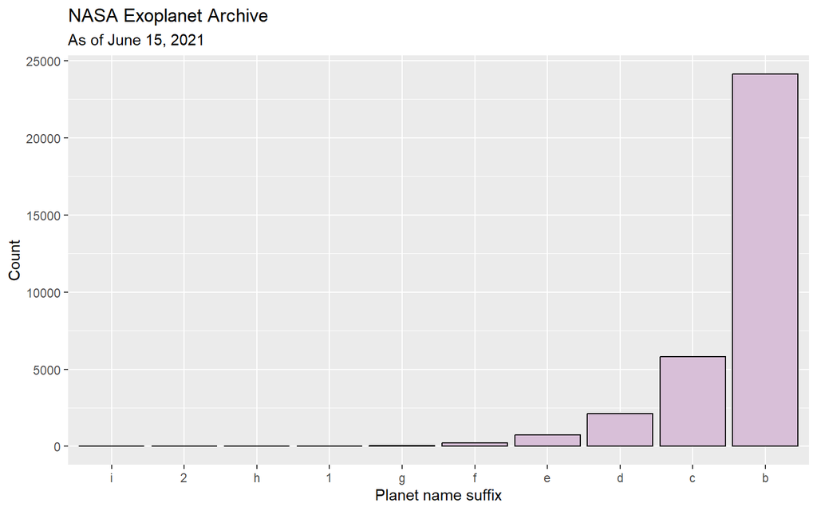

```r
planet_letters = planets %>%
  mutate(letter = str_sub(planet,-1, -1))

letter_counts = planet_letters %>% group_by(letter) %>% summarize(n = n())

ggplot(letter_counts, aes(x = reorder(letter, n), y = n)) +
  geom_col(color="black", fill="thistle") +
  labs(
      x = "Planet name suffix",
      y = "Count",
      title = "NASA Exoplanet Archive",
      subtitle = "As of June 15, 2021"
    )
```

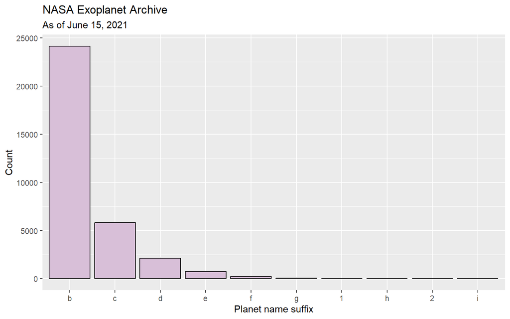

```r
ggplot(letter_counts, aes(x = reorder(letter, desc(n)), y = n)) +
  geom_col(color="black", fill="thistle") +
  labs(
      x = "Planet name suffix",
      y = "Count",
      title = "NASA Exoplanet Archive",
      subtitle = "As of June 15, 2021"
    )
```

## “c”’s Without “b”’s

> Are there any planets in the data set whose name ends in ” c” for which there is not a corresponding planet in the same stellar system whose name ends ” b”?

```r
# Live coding
```

## Planet Naming Patterns

> Most planets have a name that matches the star name followed by a space and a lower case letter. Identify any planets that do not follow this pattern.
- The simple approach here can fail if the star name contains characters with special meaning in a regular expression.

```r
# Live coding
```

```r
# Live coding
```